# The Annotated GraphIE

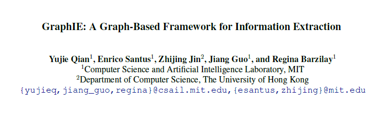

```python
from IPython.display import Image
Image(filename='images/header.png')
```

## Abstract

Most modern Information Extraction (IE) systems are implemented as sequential taggers and only model local dependencies. Non-local and non-sequential context is, however, a valuable source of information to improve predictions. In this paper, we introduce GraphIE, a framework that operates over a graph representing a broad set of dependencies between textual units (i.e. words or sentences). The algorithm propagates information between connected nodes through graph convolutions, generating a richer representation that can be exploited to improve word-level predictions. Evaluation on three different tasks — namely textual, social media and visual information extraction — shows that GraphIE consistently outperforms the state-of-the-art sequence tagging model by a significant margin.

> This annotated paper has been created as part of the course [New Developments in NN Architectures and Representation Learning for NLU Tasks](https://www.cl.uni-heidelberg.de/courses/ss19/NNARL/).

> The original paper can be found [here](https://arxiv.org/abs/1810.13083).

> The code is taken from the repository of the papers authors, which is available on [Github](https://github.com/thomas0809/GraphIE).

> The code for the results part is completely self-made.

> This annotated paper contains only the word-level adaptation and application on the CoNLL-2003 dataset (Task 1).

> Both code and paper text have been modified. The code has been put together and simplified for better understanding. The paper text has been rearranged to provide an explanation flow. Some parts not relevant have been removed.

> My annotations are green and bold.

## Prelims

```python
# !pip install git+git://github.com/zhijing-jin/efficiency.git tensorboardX==1.4.0 scipy nltk
```

> Requires also Python >= 3.6 and PyTorch 0.4.0 according to CUDA version.

```python
# ALL the imports
import torch
import torch.nn as nn
import torch.nn.functional as F

import pdb
import sys
import os
import subprocess
import gc
import time

import json
import time
import argparse
import random

import numpy as np
from decimal import Decimal

from efficiency.log import show_time, show_var, fwrite

from neuronlp2.nn import ChainCRF, WeightDropLSTM
from neuronlp2.nn import embedded_dropout
from neuronlp2.models import BiRecurrentConvCRF
from neuronlp2 import utils
from neuronlp2.nn import utils as nn_utils
from neuronlp2.io.Constants import PAD_ID_WORD
from neuronlp2.nn._functions import GELU
from neuronlp2.nn import Optimizer
from neuronlp2.io import get_logger, LogInfo, conll03_data, CoNLL03Writer, \
    TensorboardLossRecord, LossRecorder, plot_att_change
from neuronlp2.nn.modules.transformer import PositionEncoder, LayerNormalization, get_attn_padding_mask, get_attn_adj_mask

sys.path.append(".")
sys.path.append("..")
homedir = os.path.expanduser('~')

options_file = '../../data/elmo/elmo_2x4096_512_2048cnn_2xhighway_options.json'
weight_file = '../../data/elmo/elmo_2x4096_512_2048cnn_2xhighway_weights.hdf5'
```

## Introduction

Most modern Information Extraction (IE) systems are implemented as sequential taggers. While such models effectively capture relations in the local context, they have limited capability of exploiting non-local and non-sequential dependencies. In many applications, however, such dependencies can greatly reduce tagging ambiguity, thereby improving overall extraction performance. For instance, when extracting entities from a document, various types of non-local contextual information such as co-references and identical mentions may provide valuable cues. See for example Figure 1, in which the non-local relations are crucial to discriminate the entity type of the second mention of Washington (i.e. PERSON , ORGANIZATION or LOCATION ).

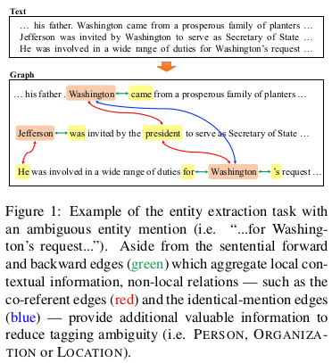

```python
Image(filename='images/figure1.png')
```

Most of the prior work looking at the non-local dependencies incorporates them by constraining the output space in a structured prediction framework (*Finkel et al., 2005; Reichart and Barzilay, 2012; Hu et al., 2016*). Such approaches, however, mostly overlook the richer set of structural relations in the input space. With reference to the example in Figure 1, the co-referent dependencies would not be readily exploited by simply constraining the output space, as they would not necessarily be labeled as entities (e.g. pronouns). In the attempt to capture non-local dependencies in the input space, alternative approaches define a graph that outlines the input structure and engineer features to describe it (*Quirk and Poon, 2017*). Designing effective features is however challenging, arbitrary and time consuming, especially when the underlying structure is complex. Moreover, these approaches have limited capacity of capturing node interactions informed by the graph structure.

In this paper, we propose GraphIE, a framework that improves predictions by automatically learning the interactions between local and non-local dependencies in the input space. Our approach integrates a graph module with the encoder-decoder architecture for sequence tagging. The algorithm operates over a graph, where nodes correspond to textual units (i.e. words or sentences) and edges describe their relations. At the core of our model, a recurrent neural network sequentially encodes local contextual representations and then the graph module iteratively propagates information between neighboring nodes using graph convolutions (*Kipf and Welling, 2016*). The learned representations are finally projected back to a recurrent decoder to support tagging at the word level.

## Related Work

The problem of incorporating non-local and non-sequential context to improve information extraction has been extensively studied in the literature. The majority of methods have focused on enforcing constraints in the output space during inference, through various mechanisms such as posterior regularization or generalized expectations (*Finkel et al., 2005; Mann and McCallum, 2010; Reichart and Barzilay, 2012; Li et al., 2013; Hu et al., 2016*). Research capturing non-local dependencies in the input space have mostly relied on featurebased approaches. *Roberts et al. (2008)* and *Swampillai and Stevenson (2011)* have designed intra- and inter-sentential features based on discourse and syntactic dependencies (e.g., shortest paths) to improve relation extraction. *Quirk and Poon (2017)* used document graphs to flexibly represent multiple types of relations between words (e.g., syntactic, adjacency and discourse relations).

**Graph-based representations can be also learned with neural networks. The most related work to ours is the graph convolutional network by *Kipf and Welling (2016)*, which was developed to encode graph structures and perform node classification. In our framework, we adapt GCN as an intermediate module that learns non-local context, which — instead of being used directly for classification — is projected to the decoder to enrich local information and perform sequence tagging.**

## Problem Definition

We formalize information extraction as a sequence tagging problem. Rather than simply modeling inputs as sequences, we assume there exists a graph structure in the data that can be exploited to capture non-local and non-sequential dependencies between textual units, namely words or sentences. We consider the input to be a set of sentences $S = {s_1 , . . . , s_N }$ and an auxiliary graph $G = (V, E)$, where $V = {v_1 , . . . , v_M }$ is the node set and $E ⊂ V × V$ is the edge set. Each sentence is a sequence of words. We consider two different designs of the graph:

(1) *sentence-level graph*, where each node is a sentence (i.e. $M = N$ ), and the edges encode sentence dependencies;

(2) *word-level graph*, where each node is a word (i.e. $M$ is the number of words in the input), and the edges connect pairs of words, such as co-referent tokens.

The edges $e_{i,j} = (v_i , v_j )$ in the graph can be either directed or undirected. Multiple edge types can also be defined to capture different structural factors underlying the task-specific input data.

We use the BIO (Begin, Inside, Outside) tagging scheme in this paper. For each sentence $s_i = (w_1^{(i)} , w_2^{(i)} , . . . , w_k^{(i)} ),$ we sequentially tag each word as $y_i = (y_1^{(i)} , y_2^{(i)} , . . . , y_k^{(i)} )$.

## Method

GraphIE jointly learns local and non-local dependencies by iteratively propagating information between node representations. Our model has three components:

• an *encoder*, which generates local contextaware hidden representations for the textual unit (i.e. word or sentence, depending on the task) with a recurrent neural network;

• a *graph module*, which captures the graph structure, learning non-local and non-sequential dependencies between textual units;

• a *decoder*, which exploits the contextual information generated by the graph module to perform labelling at the word level.

The next figure illustrates the overview of GraphIE.

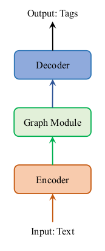

```python
Image(filename='images/design_overview.png')
```

### Graph Module

The graph module is designed to learn the non-local and non-sequential information from the graph. We adapt the graph convolutional network (GCN) to model the graph context for information extraction.

Given the sentence-level graph $G = (V, E)$, where each node $v_i$ (i.e. sentence $s_i$ ) has the encoding $Enc(s_i)$ capturing its local information, the graph module enriches such representation with neighbor information derived from the graph structure.

Our graph module is a GCN which takes as input the sentence representation, i.e. $g_i = Enc(s_i)$, and conducts graph convolution on every node, propagating information between its neighbors, and integrating such information into a new hidden representation. Specifically, each layer of GCN has two parts. The first gets the information of each node from the previous layer, i.e.

$$\alpha_i^{(l)} = W_v^{(l)} g_i^{(l-1)} \ \ \ \ (2)$$

where $W_v^{(l)}$ is the weight to be learned. The second aggregates information from the neighbors of each node, i.e. for node $v_i$ , we have

$$\beta_i^{(l)} = \frac{1}{d(v_i)} * W_e{(l)} \Bigg(\sum_{e_{i,j} \in E} g_j^{(l-1)}\Bigg) \ \ \ \ (3)$$

where $d(v_i)$ is the degree of node $v_i$ (i.e. the number of edges connected to $v_i$ ) and is used to normalize $β_i^{(l)}$ , ensuring that nodes with different degrees have representations of the same scale. In the simplest case, where the edges in the graph are undirected and have the same type, we use the same weight $W_e^{(l)}$ for all of them. In a more general case, where multiple edge types exist, we expect them to have different impacts on the aggregation. Thus, we model these edge types with different weights in Eq. 3, similar to the relational GCN proposed by *Schlichtkrull et al. (2018)*. When edges are directed, i.e. edge $e_{i,j}$ is different from $e_{j,i}$ , the propagation mechanism should mirror such difference. In this case, we consider directed edges as two types of edges (forward and backward), and use different weights for them.

Finally, $α_i^{(l)}$ and $β_i^{(l)}$ are combined to obtain the representation at the $l$-th layer,

$$ g_i^{(l)} = \sigma \big(\alpha_i^{(l)} + \beta_i^{(l)} + b^{(l)}\big) \ \ \ \ (4)$$

where $σ(·)$ is the non-linear activation function, and $b^{(l)}$ is a bias parameter.

Because each layer only propagates information between directly connected nodes, we can stack multiple graph convolutional layers to get a larger receptive field, i.e. each node can be aware of more distant neighbors. After $L$ layers, for each node $v_i$ we obtain a contextual representation, $GCN(s_i) = g_i^{(L)}$ , that captures both local and non-local information.

```python
class GCN(nn.Module):

    def __init__(self, gcn_model, n_gcn_layer, d_graph, d_in, p_gcn,
                 n_head=4, d_inner_hid=256, d_k=32, d_v=32,
                 position_enc_mode="lookup", globalnode=False,
                 adj_attn_type=''):
        super(GCN, self).__init__()

        self.gcn_model = gcn_model
        n_graph = 3 if gcn_model == 'gnn' else 1
        self.adj_attn_type = adj_attn_type

        self.to_graph = nn.Linear(d_in, d_graph)
        self.dropout_gcn_in = nn.Dropout(p_gcn[0])

        self.position_enc = PositionEncoder(d_graph, mode=position_enc_mode)

        self.gcn_layers = nn.ModuleList([
            GNN_Layer(d_graph, d_graph, p_gcn[1], n_graph=n_graph)
            for _ in range(n_gcn_layer)
        ])


    def forward(self, h_gcn, adjs, doc_word_mask):

        gcn_model = self.gcn_model

        posi = [sent.nonzero().view(-1) for sent in doc_word_mask]
        posi = torch.stack(posi) + 1

        batch_size, n_node = h_gcn.size()[:2]

        slf_attn_pad_mask = get_attn_padding_mask(doc_word_mask, doc_word_mask)

        if len(self.gcn_layers) > 0:

            h_gcn = self.dropout_gcn_in(F.elu(self.to_graph(h_gcn)))

            h_gcn = h_gcn + self.position_enc(posi, h_gcn)

        adjs = adjs if gcn_model in ['gnn', 'gnn1'] else adjs.squeeze(1)

        slf_attn_adj_mask = get_attn_adj_mask(adjs)

        opts = (adjs, doc_word_mask)

        for layer_i, layer in enumerate(self.gcn_layers):
            h_gcn, edge_weig = layer(h_gcn, *opts)

        h_gcn = h_gcn.view(batch_size, n_node, -1)

        return h_gcn,


# One layer of the GCN
class GNN_Layer(nn.Module):

    def __init__(self, d_input, d_model, p_gcn, n_graph=1):
        super(GNN_Layer, self).__init__()
        self.linear_gcn = nn.Linear(d_input * n_graph, d_model)
        self.n_graph = n_graph

        self.elu = GELU()
        self.norm = LayerNormalization(d_model)
        self.dropout = nn.Dropout(p=p_gcn)

    def forward(self, x, adjs, mask=None):
        assert len(adjs.size()) == 4
        batch, n_node, _ = x.size()
        assert adjs.size(1) == self.n_graph

        # first part
        h = x.clone()
        # second part
        x = x.unsqueeze(1).expand(-1, self.n_graph, -1, -1)
        # aggretate information from neighboring nodes
        h_gcn = torch.matmul(adjs, x).transpose(1, 2).contiguous().view(batch, n_node, -1)
        h_gcn = self.linear_gcn(h_gcn)
        # degree of node
        d = adjs.sum(dim=3).sum(dim=1).unsqueeze(2)
        d = d + d.eq(0).float()
        # divide by the degree to normalize and add it all together
        h = h + h_gcn / d

        # non-linear activation function
        h = self.elu(h)
        h = self.norm(h)
        h = self.dropout(h)
        return h, None
```

> For more details about the GCN, please look up the paper of *Kipf and Welling (2016)* and also *Schlichtkrull et al. (2018)*

### Encoder

In GraphIE, we first use an encoder to generate text representations. Given a sentence $s_i = (w_1^{(i)} , w_2^{(i)} , . . . , w_k^{(i)} )$ of length $k$, each word $w_t^{(i)}$ is represented by a vector $x_t$ , which is the concatenation of its word embedding and a feature vector learned with a character-level convolutional neural network (CharCNN; *Kim et al. (2016)*). We encode the sentence with a recurrent neural network (RNN), defining it as

$$ h_{1:k}^{(i)} = RNN \ \big(x_{1:k}^{(i)} ; 0, Θ_{enc}\big) \ , \ \ (1) $$

where $x_{1:k}^{(i)}$ denotes the input sequence $[x_1^{(i)} , · · · , x_k^{(i)} ]$, $h_{1:k}^{(i)}$ denotes the hidden states $[h_1 , · · · , h_k ]$, 0 indicates the initial hidden state is zero, and $Θ_enc$ represents the encoder parameters. We implement the RNN as a bi-directional LSTM (Hochreiter and Schmidhuber, 1997), and encode each sentence independently.

We obtain the sentence representation for $s_i$ by averaging the hidden states of its words, i.e. $Enc(s_i ) = \frac{1}{k} \big(\sum_{t=1}^{k}h_t^{(i)}\big)$. The sentence representations are then fed into the graph module.

### Decoder

To support tagging, the learned representation is propagated to the decoder.

In our work, the decoder is instantiated as a BiLSTM+CRF tagger (*Lample et al., 2016*). The output representation of the graph module, $GCN(s_i)$, is split into two vectors of the same length, which are used as the initial hidden states for the forward and backward LSTMs, respectively. In this way, the graph contextual information is propagated to each word through the LSTM. Specifically, we have

$$ z_{1:k}^{(i)} = RNN\ \ \big( h_{1:k}^{(i)} ; GCN(s_i), Θ_{dec} \big) \ ,\ \ \ \ (5)$$

where $h_{1:k}^{(i)}$ are the output hidden states of the encoder, $GCN(s_i)$ represents the initial state, and $Θ_{dec}$ is the decoder parameters. A simpler way to incorporate the graph representation into the decoder is concatenating with its input, but the empirical performance is worse than using as the initial state.

Finally, we use a CRF layer (*Lafferty et al., 2001*) on top of the BiLSTM to perform tagging,

$$ y_i^∗ = arg max_{y∈Y_k} p \big(y \ | \ z_{1:k}^{(i)} ; Θ_{crf}\big) \ , \ \ \ \ (6) $$

where $Y_k$ is the set of all possible tag sequences of length $k$, and $Θ_{crf}$ represents the CRF parameters, i.e. transition scores of tags. CRF combines the local predictions of BiLSTM and the transition scores to model the joint probability of the tag sequence.

#### Adaptation to word-level Graph

GraphIE can be easily adapted to model word-level graphs. In such case, the nodes represent words in the input, i.e. the number of nodes $M$ equals the total number of words in the $N$ sentences. At this point, each word’s hidden state in the encoder can be used as the input node vector $ g_i^{(0)} $ of the graph module. GCN can then conduct graph convolution on the word-level graph and generate graph-contextualized representations for the words. Finally, the decoder directly operates on the GCN’s outputs, i.e. we change the BiLSTM decoder to

$$z_{1:k}^{(i)} = RNN \big( \big[GCN(w_1^{(i)} ), · · · , GCN(w_k^{(i)} )\big] ; \ 0,\ Θ_{dec}\big) ,$$

where $GCN(w_t^{(i)})$ is the GCN output for word $w_t^{(i)}$ . In this case, the BiLSTM initial states are set to the default zero vectors. The CRF layer remains unchanged.

As it can be seen in the next Figure, the word-level graph module differs from the sentence-level one because it directly takes the word representations from the encoder and feeds its output to the decoder. In sentence-level graph, the GCN operates on sentence representations, which are then used as the initial states of the decoder BiLSTM.

The figure below shows the model architectures for sentence-level and word-level graphs.

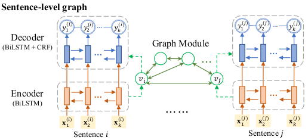

```python
Image(filename='images/sentence-level-graph.png')
```

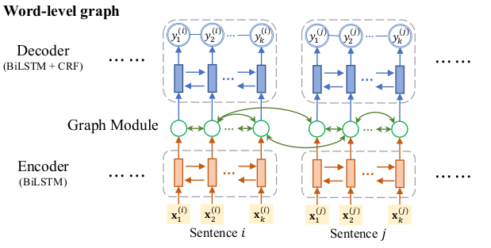

```python
Image(filename='images/word-level-graph.png')
```

> In this example, we only use the word-level version.

```python
# As in the text described, GraphIE is based on SeqIE, which is a encoder-decoder with BiLSTMs and a CRF

class BiRecurrentConvGraphCRF(BiRecurrentConvCRF):

    def __init__(self, word_dim, num_words, char_dim, num_chars, char_hidden_size, kernel_size, rnn_mode, encoder_mode,
                 hidden_size, num_layers, num_labels,
                 gcn_model, n_head, d_graph, d_inner_hid, d_k, d_v, p_gcn, n_gcn_layer,
                 d_out, post_lstm=1, mask_singles=False, position_enc_mode="lookup", adj_attn='',
                 adj_loss_lambda=0,
                 char_method='cnn', tag_space=0, embedd_word=None, embedd_char=None, use_elmo=False, p_em_vec=0.0,
                 p_em=0.33, p_in=0.33, p_tag=0.5, p_rnn=(0.5, 0.5, 0.5), p_rnn2=(0.5, 0.5, 0.5), bigram=False,
                 initializer=None):

        super(BiRecurrentConvGraphCRF, self).__init__(word_dim, num_words, char_dim, num_chars, char_hidden_size,
                                                      kernel_size, rnn_mode, encoder_mode, hidden_size, num_layers,
                                                      num_labels, char_method=char_method,
                                                      tag_space=tag_space, embedd_word=embedd_word,
                                                      embedd_char=embedd_char, use_elmo=use_elmo, p_em_vec=p_em_vec,
                                                      p_em=p_em,
                                                      p_in=p_in, p_tag=p_tag, p_rnn=p_rnn, bigram=bigram,
                                                      initializer=initializer)
        self.post_lstm = post_lstm
        self.mask_singles = mask_singles

        # the new things is, that we now use GCN between encoder and decoder to incorporate non-local information
        self.gcn = GCN(gcn_model, n_gcn_layer, d_graph, hidden_size, p_gcn,
                       n_head=n_head, d_inner_hid=d_inner_hid, d_k=d_k, d_v=d_v,
                       position_enc_mode=position_enc_mode, globalnode=False, adj_attn_type=adj_attn)

        d_rnn2_in = d_graph if n_gcn_layer > 0 else hidden_size
        if post_lstm:
            self.dropout_rnn2_in = nn.Dropout(p_rnn2[0])
            self.rnn2 = self.RNN(d_rnn2_in, d_out // 2, num_layers=num_layers,
                                 batch_first=True, bidirectional=True, dropout=p_rnn2[1])
            self.dropout_rnn2_out = nn.Dropout(p_rnn2[2])

        if tag_space:
            if not post_lstm:
                d_out = d_rnn2_in
            self.dropout_tag = nn.Dropout(p_tag)
            self.to_tag_space = nn.Linear(d_out, tag_space)

    # the encoder
    def _get_rnn_enc2(self, encoding, length, mask, hx, show_net=False):

        # prepare packed_sequence
        encoding = self.dropout_rnn2_in(encoding)

        if length is not None:
            seq_input, hx, rev_order, mask = nn_utils.prepare_rnn_seq(
                encoding, length, hx=hx, masks=mask, batch_first=True)
            seq_output, hn = self.rnn2(seq_input, hx=hx)
            output, hn = nn_utils.recover_rnn_seq(
                seq_output, rev_order, hx=hn, batch_first=True)

        else:
            output, hn = self.rnn2(encoding, hx=hx)

        # here we generate the encoding
        output = self.dropout_rnn2_out(output)

        return output, hn

    def forward(self, input_word_orig, input_word, input_char, adjs, target, mask=None, length=None, hx=None,
                leading_symbolic=0, return_edge=False):
        assert len(input_word.size()) == 3, "the input is not document level"
        # input_word is the packed sents [n_sent, sent_len]

        return input_word[0]

        return self.loss(input_word_orig, input_word, input_char, adjs, target, mask=mask, length=length, hx=hx,
                         leading_symbolic=leading_symbolic, return_edge=return_edge)

    # the graph module in the middle
    def _get_gcn_output(self, input_word_orig, input_word, input_char, adjs, target=None, mask=None, length=None,
                        hx=None, leading_symbolic=0, return_edge=False, show_net=False, graph_types=['coref']):
        if "wonderful" in graph_types:
            gold_adj = adjs[:, -1, :].clone()
            gnn_adjs = adjs[:, :-1, :]

        mask_singles = self.mask_singles

        assert len(input_word.size()) == 3, "the input is not document level"
        # input_word is the packed sents [n_sent, sent_len]
        input_word, input_char, target, sent_mask, length, doc_n_sent = self._doc2sent(
            input_word, input_char, target, show_net=show_net)

        # input: [n_sent, sent_len, enc_dim]
        input, length = self._get_word_enc(
            input_word_orig, input_word, input_char, mask=sent_mask, length=length, show_net=show_net)

        # output from rnn [n_sent, sent_len, enc_dim]
        sent_output, hn = self._get_rnn_enc(input, length, sent_mask, hx, show_net=show_net)

        # flatten sents to words [batch, n_word, dim]
        # mask for packed_doc [batch, n_word]
        output, doc_word_mask = self._sent2word(sent_output, sent_mask, doc_n_sent, show_net=show_net)

        if mask_singles:

            coref_ix = 0
            single_mask = gnn_adjs[:, coref_ix].sum(-1, keepdim=True).eq(0).float()
            sent_single_mask = self._word2sent(single_mask, doc_word_mask, length, sent_mask, show_net=show_net)
            singles = sent_output * sent_single_mask.expand_as(sent_output)
            if self.tag_space:
                singles = self.dropout_tag(
                    F.elu(self.lstm_to_tag_space(singles)))
                singles = singles * sent_single_mask.expand_as(singles)

            output = output * (1 - single_mask).expand_as(output)

        h_gcn, *_ = self.gcn(output, gnn_adjs,
                             doc_word_mask)

        output = self._word2sent(h_gcn, doc_word_mask, length, sent_mask, show_net=show_net)

        if self.post_lstm:
            # output from rnn [n_sent, sent_len, enc_dim]
            output, hn = self._get_rnn_enc2(output, length, sent_mask, hx, show_net=show_net)

        # output from rnn_out [batch, length, tag_space]
        output = self.dropout_tag(F.elu(self.to_tag_space(output)))

        if mask_singles:
            output = output * (1 - sent_single_mask).expand_as(output)
            output = output + singles  # repetive word enc + single word enc

        if length is not None:
            max_len = length.max()
            target = target[:, :max_len]

        # return output of the gcn
        adj_loss = self._adj_loss(gnn_adjs[:, 0, :], gold_adj) if "wonderful" in graph_types else 0
        return output, target, sent_mask, length, adj_loss

    def _adj_loss(self, coref_adj, gold_adj):
        '''
        This is the same as an average of element_wise cross_entropy
        The only constraint is (coref_adj.shape == gold_adj.shape)
        :param coref_adj: a matrix of 0~1 values
        :param gold_adj: a matrix, (gold_adj.sum(-1) == 1).all() == True
        :return: loss
        '''
        loss_fn = nn.BCELoss()
        softmax = nn.Softmax()

        assert (coref_adj.shape == gold_adj.shape)

        coref_adj_for_comp = torch.clamp(coref_adj, 0., 1.)

        return loss_fn(coref_adj_for_comp, gold_adj)

    def loss(self, input_word_orig, input_word, input_char, adjs, target, graph_types=['coref'],
             lambda1=1., lambda2=0.,
             mask=None, length=None, hx=None, leading_symbolic=0, return_edge=False, show_net=False):
        output, target, sent_mask, _, adj_loss = self._get_gcn_output(input_word_orig, input_word, input_char, adjs,
                                                                      target,
                                                                      mask=mask, length=length, hx=hx,
                                                                      leading_symbolic=leading_symbolic,
                                                                      return_edge=return_edge,
                                                                      show_net=show_net, graph_types=graph_types)

        ner_loss = self.crf.loss(output, target, mask=sent_mask).mean()
        total_loss = lambda1 * ner_loss + lambda2 * adj_loss
        return total_loss, (ner_loss, adj_loss)

    # the decoder
    def decode(self, input_word_orig, input_word, input_char, adjs, target=None, mask=None, length=None, hx=None,
               leading_symbolic=0, graph_types=['coref']):

        # we take the output of the GCN
        output, target, sent_mask, length, _ = self._get_gcn_output(input_word_orig, input_word, input_char, adjs,
                                                                    target,
                                                                    mask=mask, length=length, hx=hx,
                                                                    leading_symbolic=leading_symbolic,
                                                                    graph_types=graph_types)

        if target is None:
            return self.crf.decode(output, mask=sent_mask, leading_symbolic=leading_symbolic), None

        # we get our predictions here
        preds = self.crf.decode(output, mask=sent_mask,
                                leading_symbolic=leading_symbolic)
        if mask is None:
            return preds, torch.eq(preds, target).float().sum()
        else:
            return preds, (torch.eq(preds, target).float() * sent_mask).sum()
```

## Task 1: Textual Information Extraction

In this task, we focus on named entity recognition at discourse level (DiscNER). In contrast to traditional sentence-level NER (SentNER), where sentences are processed independently, in DiscNER, long-range dependencies and constraints across sentences have a crucial role in the tagging process. For instance, multiple mentions of the same entity are expected to be tagged consistently in the same discourse. Here we propose to use this (soft) constraint to improve entity extraction.

**Dataset** We conduct experiments on a NER dataset: the CoNLL-2003 dataset (CONLL03) (*Tjong et al., 2003*). We follow the standard split of the corpora, statistics are shown below.

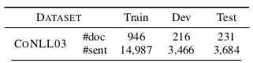

```python
Image(filename='images/dataset_statistics.png')
```

Statistics of the CONLL03 dataset (Task 1).

**Graph Construction** In this task, we use a word-level graph where nodes represent words. We create two types of edges for each document:

- *Local edges*: forward and backward edges are created between neighboring words in each sentence, allowing local contextual information to be utilized.
- *Non-local edges*: re-occurrences of the same token other than stop words are connected, so that information can be propagated through, encouraging global consistency of tagging.

### Baseline and Our Method

Our baseline shares the same encoder and decoder architecture with GraphIE, but without the graph module. Both architectures have similar computational cost. In Task 1, we apply GraphIE with word-level graph module.

### Implementation details

```python
# Set to 400 by the papers authors. We use 100 for our running.
num_epochs = 100
```

```python
learning_rate_gcn = 0.001
```

The 100-dimensional pretrained GloVe word embeddings (*Pennington et al., 2014*) are used in Task 1

```python
embedding = 'glove'
embedding_path = 'data/pretr/emb/glove.6B.100d.txt'
```

> Everything else training related:

```python
# this function calls the official conll03 evaluation script
def evaluate(output_file, score_file, evaluate_raw_format=False, o_tag='O'):

    gc.collect()
    subprocess.Popen("touch %s" % (score_file), shell=True)
    subprocess.Popen("./examples/eval/test.sh %s %s" % (output_file, score_file), shell=True)
    time.sleep(5)
    with open(score_file, 'r') as fin:
        fin.readline()
        line = fin.readline()
        fields = line.split(";")
        print(fields)
        print(float(fields[0].split(":")[1].strip()[:-1]))
        acc = float(fields[0].split(":")[1].strip()[:-1])
        precision = float(fields[1].split(":")[1].strip()[:-1])
        recall = float(fields[2].split(":")[1].strip()[:-1])
        f1 = float(fields[3].split(":")[1].strip())
    return acc, precision, recall, f1


def adjust_learning_rate(optimizer, lr):
    """Sets the learning rate"""
    for param_group in optimizer.param_groups:
        param_group['lr'] = lr


uid = show_time()
results_folder = './data/run/'
dataset_name = '03conll'
use_tensorboard = True

save_dset_dir = '{}../dset/{}/graph'.format(results_folder, dataset_name[:4])
result_file_path = '{}/{dataset}_{uid}_result'.format(results_folder, dataset=dataset_name[:4], uid=uid)

save_loss_path = '{}/{dataset}_{uid}_loss'.format(results_folder, dataset=dataset_name[:4], uid=uid)
save_lr_path = '{}/{dataset}_{uid}_lr'.format(results_folder, dataset=dataset_name[:4], uid='temp')
save_tb_path = '{}/tensorboard/'.format(results_folder)

logger = get_logger("NERCRF")
loss_recorder = LossRecorder(uid=uid)
record = TensorboardLossRecord(use_tensorboard, save_tb_path, uid=uid)

mode = 'LSTM'
encoder_mode = 'lstm'
train_path = 'data/dset/03co/train.c_w_d_dw_ds_sw_word_ibo_dic'
dev_path = 'data/dset/03co/valid.c_w_d_dw_ds_sw_word_ibo_dic'
test_path = 'data/dset/03co/test.c_w_d_dw_ds_sw_word_ibo_dic'

batch_size = 1
hidden_size = 450
char_hidden_size = 30
char_method = 'cnn'
learning_rate = 0.01
momentum = 0.9
decay_rate = 0.05
gamma = 0.0
max_norm = 10.0
schedule = 1
dropout = 'gcn'
p_em = 0.2
p_rnn = tuple([0.33, 0.5, 0.5])
p_in = 0.33
p_tag = 0.5
unk_replace = 0.0
bigram = True
evaluate_raw_format = False
o_tag = 'O'
restore = False
save_checkpoint = 'data/save/'
alphabets_folder = 'data/alphabets'
use_elmo = False
p_em_vec = 0.
graph_model = 'gnn'
coref_edge_filt = ''


gcn_warmup = 1000
pretrain_lstm = 5.0

adj_loss_lambda = 0.0
lambda1 = 1.0
lambda2 = 0.0

smooth=True
misc = '(450, 0.001, 1000, 5, 0.2, 0.33, (0.33, 0.5, 0.5), 0.5, gcn)'
seed = 5
cuda=True

if smooth:
    pdb.set_trace = lambda: None

misc = "{}".format(str(misc))

score_file = "{}{dataset}_{uid}_score".format(results_folder, dataset=dataset_name[:4], uid=uid)
print(score_file)

for folder in [results_folder, alphabets_folder, save_dset_dir]:
    if not os.path.exists(folder):
        os.makedirs(folder)

def set_seed(seed):
    if not seed:
        seed = int(show_time())
    print("[Info] seed set to: {}".format(seed))
    random.seed(seed)
    np.random.seed(seed)
    torch.manual_seed(seed)
    torch.cuda.manual_seed_all(seed)
    torch.backends.cudnn.deterministic = True

set_seed(seed)

embedd_dict, embedd_dim = utils.load_embedding_dict(embedding, embedding_path)

logger.info("Creating Alphabets")
word_alphabet, char_alphabet, ner_alphabet = conll03_data.create_alphabets(
    "{}/{}/".format(alphabets_folder, dataset_name), train_path, data_paths=[dev_path, test_path],
    embedd_dict=embedd_dict, max_vocabulary_size=50000)

logger.info("Word Alphabet Size: %d" % word_alphabet.size())
logger.info("Character Alphabet Size: %d" % char_alphabet.size())
logger.info("NER Alphabet Size: %d" % ner_alphabet.size())

logger.info("Reading Data")
device = torch.device('cpu') if cuda else torch.device('cpu')
print(device)

data_train = conll03_data.read_data(train_path, word_alphabet, char_alphabet,
                                    ner_alphabet,
                                    graph_model, batch_size, ori_order=False,
                                    total_batch="{}x".format(num_epochs + 1),
                                    unk_replace=unk_replace, device=device,
                                    save_path=save_dset_dir + '/train', coref_edge_filt=coref_edge_filt
                                    )
num_data = data_train.data_len
num_labels = ner_alphabet.size()
graph_types = data_train.meta_info['graph_types']

data_dev = conll03_data.read_data(dev_path, word_alphabet, char_alphabet,
                                  ner_alphabet,
                                  graph_model, batch_size, ori_order=True, unk_replace=unk_replace, device=device,
                                  save_path=save_dset_dir + '/dev',
                                  coref_edge_filt=coref_edge_filt)

data_test = conll03_data.read_data(test_path, word_alphabet, char_alphabet,
                                   ner_alphabet,
                                   graph_model, batch_size, ori_order=True, unk_replace=unk_replace, device=device,
                                   save_path=save_dset_dir + '/test',
                                   coref_edge_filt=coref_edge_filt)

writer = CoNLL03Writer(word_alphabet, char_alphabet, ner_alphabet)

def construct_word_embedding_table():
    scale = np.sqrt(3.0 / embedd_dim)
    table = np.empty([word_alphabet.size(), embedd_dim], dtype=np.float32)
    table[conll03_data.UNK_ID, :] = np.random.uniform(-scale, scale, [1, embedd_dim]).astype(np.float32)
    oov = 0
    for word, index in word_alphabet.items():
        if word in embedd_dict:
            embedding = embedd_dict[word]
        elif word.lower() in embedd_dict:
            embedding = embedd_dict[word.lower()]
        else:
            embedding = np.random.uniform(-scale, scale, [1, embedd_dim]).astype(np.float32)
            oov += 1
        table[index, :] = embedding
    print('oov: %d' % oov)
    return torch.from_numpy(table)

word_table = construct_word_embedding_table()
logger.info("constructing network...")

char_dim = 30
window = 3
num_layers = 1
tag_space = 128
initializer = nn.init.xavier_uniform_

p_gcn = [0.5, 0.5]

d_graph = 256
d_out = 256
d_inner_hid = 128
d_k = 32
d_v = 32
n_head = 4
n_gcn_layer = 1

p_rnn2 = [0.0, 0.5, 0.5]

adj_attn = ''
mask_singles = True
post_lstm = 1
position_enc_mode = 'none'

adj_memory = False

if dropout == 'gcn':
    network = BiRecurrentConvGraphCRF(embedd_dim, word_alphabet.size(), char_dim, char_alphabet.size(),
                                      char_hidden_size, window, mode, encoder_mode, hidden_size, num_layers,
                                      num_labels,
                                      graph_model, n_head, d_graph, d_inner_hid, d_k, d_v, p_gcn, n_gcn_layer,
                                      d_out, post_lstm=post_lstm, mask_singles=mask_singles,
                                      position_enc_mode=position_enc_mode, adj_attn=adj_attn,
                                      adj_loss_lambda=adj_loss_lambda,
                                      tag_space=tag_space, embedd_word=word_table,
                                      use_elmo=use_elmo, p_em_vec=p_em_vec, p_em=p_em, p_in=p_in, p_tag=p_tag,
                                      p_rnn=p_rnn, p_rnn2=p_rnn2,
                                      bigram=bigram, initializer=initializer)

# whether restore from trained model
if restore:
    network.load_state_dict(torch.load(save_checkpoint + '_best.pth'))  # load trained model

logger.info("cuda()ing network...")

network = network.to(device)

if dataset_name == '03conll' and data_dev.data_len > 26:
    sample = data_dev.pad_batch(data_dev.dataset[25:26])
else:
    sample = data_dev.pad_batch(data_dev.dataset[:1])
plot_att_change(sample, network, record, save_tb_path + 'att/', uid='temp', epoch=0, device=device,
                word_alphabet=word_alphabet, show_net=False,
                graph_types=data_train.meta_info['graph_types'])

logger.info("finished cuda()ing network...")
```

```
⏰ Time: 02290918-09
./data/run/03co_02290918_score
[Info] seed set to: 5
loading embedding: glove from data/pretr/emb/glove.6B.100d.txt
2020-02-29 09:18:31,981 - NERCRF - INFO - Creating Alphabets
[Info] Loading existing alphabet at: data/alphabets/03conll/
2020-02-29 09:18:32,005 - Create Alphabets - INFO - Word Alphabet Size (Singleton): 23599 (8122)
2020-02-29 09:18:32,006 - Create Alphabets - INFO - Character Alphabet Size: 89
2020-02-29 09:18:32,007 - Create Alphabets - INFO - NER Alphabet Size: 10
2020-02-29 09:18:32,009 - NERCRF - INFO - Word Alphabet Size: 23599
2020-02-29 09:18:32,010 - NERCRF - INFO - Character Alphabet Size: 89
2020-02-29 09:18:32,012 - NERCRF - INFO - NER Alphabet Size: 10
2020-02-29 09:18:32,013 - NERCRF - INFO - Reading Data
cpu
Reading data from data/dset/03co/train.c_w_d_dw_ds_sw_word_ibo_dic
[Info] Loading graph: ./data/run/../dset/03co/graph/train_graph.json
Total number of data: 947
Reading data from data/dset/03co/valid.c_w_d_dw_ds_sw_word_ibo_dic
[Info] Loading graph: ./data/run/../dset/03co/graph/dev_graph.json
Total number of data: 217
Reading data from data/dset/03co/test.c_w_d_dw_ds_sw_word_ibo_dic
[Info] Loading graph: ./data/run/../dset/03co/graph/test_graph.json
Total number of data: 232
oov: 340
2020-02-29 09:18:55,357 - NERCRF - INFO - constructing network...
2020-02-29 09:18:55,403 - NERCRF - INFO - cuda()ing network...
2020-02-29 09:18:55,447 - NERCRF - INFO - finished cuda()ing network...
```

The models are trained with Adam (*Kingma and Ba, 2014*) to minimize the CRF objective.

```python
lr = learning_rate
lr_gcn = learning_rate_gcn
optim = Optimizer('sgd', 'adam', network, dropout, lr=learning_rate,
                  lr_gcn=learning_rate_gcn,
                  wd=0., wd_gcn=0., momentum=momentum, lr_decay=decay_rate, schedule=schedule,
                  gcn_warmup=gcn_warmup,
                  pretrain_lstm=pretrain_lstm)
```

```python
nn.utils.clip_grad_norm_(network.parameters(), max_norm)
logger.info(
    "Network: %s, encoder_mode=%s, num_layer=%d, hidden=%d, char_hidden_size=%d, char_method=%s, tag_space=%d, crf=%s" % \
    (mode, encoder_mode, num_layers, hidden_size, char_hidden_size, char_method, tag_space,
     'bigram' if bigram else 'unigram'))
logger.info("training: l2: %f, (#training data: %d, batch: %d, unk replace: %.2f)" % (
    gamma, num_data, batch_size, unk_replace))
logger.info("dropout(in, out, rnn): (%.2f, %.2f, %s)" % (p_in, p_tag, p_rnn))

num_batches = num_data // batch_size + 1
dev_f1 = 0.0
dev_acc = 0.0
dev_precision = 0.0
dev_recall = 0.0
test_f1 = 0.0
test_acc = 0.0
test_precision = 0.0
test_recall = 0.0
best_epoch = 0
best_test_f1 = 0.0
best_test_acc = 0.0
best_test_precision = 0.0
best_test_recall = 0.0
best_test_epoch = 0.0

loss_recorder.start(save_loss_path, mode='w', misc=misc)
fwrite('', save_lr_path)
```

```
2020-02-29 09:19:12,464 - NERCRF - INFO - Network: LSTM, encoder_mode=lstm, num_layer=1, hidden=450, char_hidden_size=30, char_method=cnn, tag_space=128, crf=bigram
2020-02-29 09:19:12,469 - NERCRF - INFO - training: l2: 0.000000, (#training data: 946, batch: 1, unk replace: 0.00)
2020-02-29 09:19:12,470 - NERCRF - INFO - dropout(in, out, rnn): (0.33, 0.50, (0.33, 0.5, 0.5))
```

```python
# training over all epochs
for epoch in range(1, num_epochs + 1):
    show_var(['misc'])

    lr_state = 'Epoch %d (uid=%s, lr=%.2E, lr_gcn=%.2E, decay rate=%.4f): ' % (
        epoch, uid, Decimal(optim.curr_lr), Decimal(optim.curr_lr_gcn), decay_rate)
    print(lr_state)
    fwrite(lr_state[:-2] + '\n', save_lr_path, mode='a')

    train_err = 0.
    train_err2 = 0.
    train_total = 0.

    start_time = time.time()
    num_back = 0
    network.train()
    for batch_i in range(1, num_batches + 1):

        batch_doc = data_train.next()
        char, word, posi, labels, feats, adjs, words_en = [batch_doc[i] for i in [
            "chars", "word_ids", "posi", "ner_ids", "feat_ids", "adjs", "words_en"]]

        sent_word, sent_char, sent_labels, sent_mask, sent_length, _ = network._doc2sent(
            word, char, labels)

        optim.zero_grad()

        adjs_into_model = adjs if adj_memory else adjs.clone()

        loss, (ner_loss, adj_loss) = network.loss(None, word, char, adjs_into_model, labels,
                                                  graph_types=graph_types, lambda1=lambda1, lambda2=lambda2)

        loss.backward()
        optim.step()

        with torch.no_grad():
            num_inst = sent_mask.size(0)
            train_err += ner_loss * num_inst
            train_err2 += adj_loss * num_inst
            train_total += num_inst

        time_ave = (time.time() - start_time) / batch_i
        time_left = (num_batches - batch_i) * time_ave

        # update log
        if batch_i % 20 == 0:
            sys.stdout.write("\b" * num_back)
            sys.stdout.write(" " * num_back)
            sys.stdout.write("\b" * num_back)
            log_info = 'train: %d/%d loss1: %.4f, loss2: %.4f, time left (estimated): %.2fs' % (
                batch_i, num_batches, train_err / train_total, train_err2 / train_total, time_left)
            sys.stdout.write(log_info)
            sys.stdout.flush()
            num_back = len(log_info)

        optim.update(epoch, batch_i, num_batches, network)

    sys.stdout.write("\b" * num_back)
    sys.stdout.write(" " * num_back)
    sys.stdout.write("\b" * num_back)
    print('train: %d loss: %.4f, loss2: %.4f, time: %.2fs' % (
        num_batches, train_err / train_total, train_err2 / train_total, time.time() - start_time))

    # evaluate performance on dev data
    with torch.no_grad():
        network.eval()
        tmp_filename = "{}/{dataset}_{uid}_output_dev".format(results_folder, dataset=dataset_name[:4], uid=uid)

        writer.start(tmp_filename)

        for batch in data_dev:
            char, word, posi, labels, feats, adjs, words_en = [batch[i] for i in [
                "chars", "word_ids", "posi", "ner_ids", "feat_ids", "adjs", "words_en"]]
            sent_word, sent_char, sent_labels, sent_mask, sent_length, _ = network._doc2sent(
                word, char, labels)

            preds, _ = network.decode(
                None, word, char, adjs.clone(), target=labels, leading_symbolic=conll03_data.NUM_SYMBOLIC_TAGS,
                graph_types=graph_types)
            writer.write(sent_word.cpu().numpy(), preds.cpu().numpy(), sent_labels.cpu().numpy(),
                         sent_length.cpu().numpy())
        writer.close()
        acc, precision, recall, f1 = evaluate(tmp_filename, score_file, evaluate_raw_format, o_tag)
        print('dev acc: %.2f%%, precision: %.2f%%, recall: %.2f%%, F1: %.2f%%' % (acc, precision, recall, f1))

        # plot loss and attention
        record.plot_loss(epoch, train_err / train_total, f1)

        plot_att_change(sample, network, record, save_tb_path + 'att/', uid="{}_{:03d}".format(uid, epoch),
                        epoch=epoch, device=device,
                        word_alphabet=word_alphabet, show_net=False, graph_types=graph_types)

        if dev_f1 < f1:
            dev_f1 = f1
            dev_acc = acc
            dev_precision = precision
            dev_recall = recall
            best_epoch = epoch

            # evaluate on test data when better performance detected
            tmp_filename = "{}/{dataset}_{uid}_output_test".format(results_folder, dataset=dataset_name[:4],
                                                                   uid=uid)
            writer.start(tmp_filename)

            for batch in data_test:
                char, word, posi, labels, feats, adjs, words_en = [batch[i] for i in [
                    "chars", "word_ids", "posi", "ner_ids", "feat_ids", "adjs", "words_en"]]
                sent_word, sent_char, sent_labels, sent_mask, sent_length, _ = network._doc2sent(
                    word, char, labels)

                preds, _ = network.decode(
                    None, word, char, adjs.clone(), target=labels, leading_symbolic=conll03_data.NUM_SYMBOLIC_TAGS,
                    graph_types=graph_types)

                writer.write(sent_word.cpu().numpy(), preds.cpu().numpy(), sent_labels.cpu().numpy(),
                             sent_length.cpu().numpy())
            writer.close()
            test_acc, test_precision, test_recall, test_f1 = evaluate(tmp_filename, score_file, evaluate_raw_format,
                                                                      o_tag)
            if best_test_f1 < test_f1:
                best_test_acc, best_test_precision, best_test_recall, best_test_f1 = test_acc, test_precision, test_recall, test_f1
                best_test_epoch = epoch

            # save the model parameters
            if save_checkpoint:
                torch.save(network.state_dict(), save_checkpoint + '_best.pth')

        print("best dev  acc: %.2f%%, precision: %.2f%%, recall: %.2f%%, F1: %.2f%% (epoch: %d)" % (
            dev_acc, dev_precision, dev_recall, dev_f1, best_epoch))
        print("best test acc: %.2f%%, precision: %.2f%%, recall: %.2f%%, F1: %.2f%% (epoch: %d)" % (
            test_acc, test_precision, test_recall, test_f1, best_epoch))
        print("overall best test acc: %.2f%%, precision: %.2f%%, recall: %.2f%%, F1: %.2f%% (epoch: %d)" % (
            best_test_acc, best_test_precision, best_test_recall, best_test_f1, best_test_epoch))

    loss_recorder.write(epoch, train_err / train_total, train_err2 / train_total,
                        Decimal(optim.curr_lr), Decimal(optim.curr_lr_gcn), f1, best_test_f1, test_f1)
with open(result_file_path, 'a') as ofile:
    ofile.write("best dev  acc: %.2f%%, precision: %.2f%%, recall: %.2f%%, F1: %.2f%% (epoch: %d)\n" % (
        dev_acc, dev_precision, dev_recall, dev_f1, best_epoch))
    ofile.write("best test acc: %.2f%%, precision: %.2f%%, recall: %.2f%%, F1: %.2f%% (epoch: %d)\n" % (
        test_acc, test_precision, test_recall, test_f1, best_epoch))
    ofile.write("overall best test acc: %.2f%%, precision: %.2f%%, recall: %.2f%%, F1: %.2f%% (epoch: %d)\n\n" % (
        best_test_acc, best_test_precision, best_test_recall, best_test_f1, best_test_epoch))

record.close()

print('Training finished!')
```

```
misc: '(450, 0.001, 1000, 5, 0.2, 0.33, (0.33, 0.5, 0.5), 0.5, gcn)'
Epoch 1 (uid=02290918, lr=1.00E-02, lr_gcn=0.00E+00, decay rate=0.0500):
train: 20/947 loss1: 12.1666, loss2: 0.1770, time left (estimated): 89.4                                                                        train: 40/947 loss1: 10.7738, loss2: 0.1460, time left (estimated): 91.3                                                                        train: 60/94…
['accuracy:  95.57%', ' precision:  76.13%', ' recall:  73.95%', ' FB1:  75.02\n']
95.57
dev acc: 95.57%, precision: 76.13%, recall: 73.95%, F1: 75.02%
['accuracy:  94.91%', ' precision:  73.60%', ' recall:  71.88%', ' FB1:  72.73\n']
94.91
best dev  acc: 95.57%, precision: 76.13%, recall: 73.95%, F1: 75.02% (epoch: 1)
best test acc: 94.91%, precision: 73.60%, recall: 71.88%, F1: 72.73% (epoch: 1)
overall best test acc: 94.91%, precision: 73.60%, recall: 71.88%, F1: 72.73% (epoch: 1)
misc: '(450, 0.001, 1000, 5, 0.2, 0.33, (0.33, 0.5, 0.5), 0.5, gcn)'
Epoch 2 (uid=02290918, lr=9.52E-03, lr_gcn=0.00E+00, decay rate=0.0500):
train: 20/947 loss1: 3.3011, loss2: 0.1709, time left (estimated): 108.7                                                                        train: 40/947 loss1: 3.1475, loss2: 0.1415, time left (estimated): 106.8                                                                        train: 60/94…
['accuracy:  96.71%', ' precision:  82.93%', ' recall:  81.18%', ' FB1:  82.05\n']
96.71
dev acc: 96.71%, precision: 82.93%, recall: 81.18%, F1: 82.05%
['accuracy:  96.03%', ' precision:  79.62%', ' recall:  77.96%', ' FB1:  78.78\n']
96.03
best dev  acc: 96.71%, precision: 82.93%, recall: 81.18%, F1: 82.05% (epoch: 2)
best test acc: 96.03%, precision: 79.62%, recall: 77.96%, F1: 78.78% (epoch: 2)
overall best test acc: 96.03%, precision: 79.62%, recall: 77.96%, F1: 78.78% (epoch: 2)
misc: '(450, 0.001, 1000, 5, 0.2, 0.33, (0.33, 0.5, 0.5), 0.5, gcn)'
Epoch 3 (uid=02290918, lr=9.09E-03, lr_gcn=0.00E+00, decay rate=0.0500):
train: 20/947 loss1: 3.0024, loss2: 0.1653, time left (estimated): 86.70                                                                        train: 40/947 loss1: 2.4880, loss2: 0.1350, time left (estimated): 95.14                                                                        train: 60/94…
['accuracy:  97.18%', ' precision:  85.10%', ' recall:  84.30%', ' FB1:  84.70\n']
97.18
dev acc: 97.18%, precision: 85.10%, recall: 84.30%, F1: 84.70%
['accuracy:  96.16%', ' precision:  81.10%', ' recall:  80.44%', ' FB1:  80.76\n']
96.16
best dev  acc: 97.18%, precision: 85.10%, recall: 84.30%, F1: 84.70% (epoch: 3)
best test acc: 96.16%, precision: 81.10%, recall: 80.44%, F1: 80.76% (epoch: 3)
overall best test acc: 96.16%, precision: 81.10%, recall: 80.44%, F1: 80.76% (epoch: 3)
misc: '(450, 0.001, 1000, 5, 0.2, 0.33, (0.33, 0.5, 0.5), 0.5, gcn)'
Epoch 4 (uid=02290918, lr=8.70E-03, lr_gcn=0.00E+00, decay rate=0.0500):
train: 20/947 loss1: 2.1156, loss2: 0.1603, time left (estimated): 89.00                                                                        train: 40/947 loss1: 2.1409, loss2: 0.1312, time left (estimated): 98.87                                                                        train: 60/94…
['accuracy:  97.29%', ' precision:  86.39%', ' recall:  85.26%', ' FB1:  85.82\n']
97.29
dev acc: 97.29%, precision: 86.39%, recall: 85.26%, F1: 85.82%
['accuracy:  96.43%', ' precision:  82.71%', ' recall:  81.66%', ' FB1:  82.18\n']
```

[output cut: 902 more lines]

```
98.97
dev acc: 98.97%, precision: 94.67%, recall: 94.67%, F1: 94.67%
best dev  acc: 99.04%, precision: 94.99%, recall: 94.82%, F1: 94.90% (epoch: 95)
best test acc: 98.23%, precision: 91.09%, recall: 91.40%, F1: 91.24% (epoch: 95)
overall best test acc: 98.20%, precision: 90.87%, recall: 91.63%, F1: 91.25% (epoch: 65)
misc: '(450, 0.001, 1000, 5, 0.2, 0.33, (0.33, 0.5, 0.5), 0.5, gcn)'
Epoch 100 (uid=02290918, lr=1.68E-03, lr_gcn=1.68E-04, decay rate=0.0500):
train: 20/947 loss1: 0.3408, loss2: 0.1258, time left (estimated): 117.0                                                                        train: 40/947 loss1: 0.3481, loss2: 0.1008, time left (estimated): 107.7                                                                        train: 60/94…
['accuracy:  99.03%', ' precision:  94.73%', ' recall:  94.73%', ' FB1:  94.73\n']
99.03
dev acc: 99.03%, precision: 94.73%, recall: 94.73%, F1: 94.73%
best dev  acc: 99.04%, precision: 94.99%, recall: 94.82%, F1: 94.90% (epoch: 95)
best test acc: 98.23%, precision: 91.09%, recall: 91.40%, F1: 91.24% (epoch: 95)
overall best test acc: 98.20%, precision: 90.87%, recall: 91.63%, F1: 91.25% (epoch: 65)
Training finished!
```

## Results

For CONLL03, we list the performance of existing approaches. Our baseline SeqIE obtains competitive scores compared to the best methods. The fact that GraphIE significantly outperforms it, highlights once more the importance of modeling non-local and non-sequential dependencies and confirms that our approach is an appropriate method to achieve this goal.

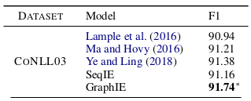

```python
Image(filename='images/results.png')
```

NER accuracy on the CONLL03 dataset (Task 1). Scores for our methods are the average of 5 runs. * indicates statistical significance of the improvement over SeqIE (p < 0.01).

**Analysis** To understand the advantage of GraphIE, we first investigate the importance of graph structure to the model. As shown in Figure 3, using random connections clearly hurts the performance, bringing down the F1 score of GraphIE from 95.12% to 94.29%

> Notably, it drops below the performance of normal SeqIE, which has no additional structure.

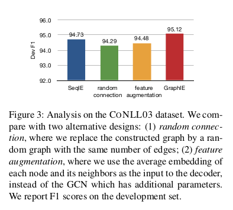

```python
Image(filename='images/fig3-analysis.png')
```

It indicates that the task-specific graph structures introduce beneficial inductive bias. Trivial feature augmentation also does not work well, confirming the necessity of learning the graph embedding with GCN.

We further conduct error analysis on the test set to validate our motivation that GraphIE resolves tagging ambiguity by encouraging consistency among identical entity mentions (cf. Figure 1). Here we examine the word-level tagging accuracy. We define the words that have more than one possible tags in the dataset as ambiguous.

> We use the data given in the repository by the authors to show reproducible results

```python
graphie_files = ["outputs/conll03_GraphIE/11131230r10_test", "outputs/conll03_GraphIE/11131129r09_test", "outputs/conll03_GraphIE/11131159r09_test", "outputs/conll03_GraphIE/11131158r09_test", "outputs/conll03_GraphIE/11131229r10_test", "outputs/conll03_GraphIE/11141004r03_test"]
seqie_files = ["outputs/conll03_SeqIE/11141152r09_test", "outputs/conll03_SeqIE/11141150r09_test", "outputs/conll03_SeqIE/11141153r09_test", "outputs/conll03_SeqIE/11141155r11_test", "outputs/conll03_SeqIE/11141156r11_test"]

data_files = ["data/dset/03co/train.c_w_d_dw_ds_sw_word_ibo_dic", "data/dset/03co/test.c_w_d_dw_ds_sw_word_ibo_dic", "data/dset/03co/valid.c_w_d_dw_ds_sw_word_ibo_dic"]

graph_over_seq = 0
seq_over_graph = 0
both = 0

graph_ambig = 0
seq_ambig = 0
graph_unambig = 0
seq_unambig = 0

d = dict()
ambiguous = []
amb = []

total = 50350 # Fix this value to not compute it every time

g_err_tot = []
g_err_a_l = []
g_err_ua_l = []
s_err_tot = []
s_err_a_l = []
s_err_ua_l = []
```

```python
### Check for ambiguous words (having 2+ tags)
for data_file in data_files:
    with open(data_file, 'r') as f1:

        for line in f1:

            g = line.strip()
            g_content = g.split("\t")

            if (len(g_content) == 9):
                word = g_content[6]
                label = g_content[7]

            if word in d:
                if (d[word] != label):
                    ambiguous.append((word, d[word], label))
                    if word not in amb:
                        amb.append(word)
            else:
                d[word] = label
```

```python
## Show some examples for ambiguous words
print("Number of ambiguous words: " + str(len(amb)))
print("Examples of ambiguous words:")
print(ambiguous[10])
print(ambiguous[42])
print(ambiguous[100])
print(ambiguous[200])
print(ambiguous[1000])
print(ambiguous[1337])
print(ambiguous[10000])
```

```
Number of ambiguous words: 2472
Examples of ambiguous words:
('Shen', 'B-PER', 'B-ORG')
('Kurdish', 'B-MISC', 'I-MISC')
('Prescott', 'I-PER', 'B-PER')
('Johnson', 'I-PER', 'B-PER')
('BRUSSELS', 'B-LOC', 'B-MISC')
('Enderle', 'I-PER', 'B-PER')
('Randall', 'I-PER', 'B-PER')
```

```python
### Evaluate errors and categorize for ambiguous or not // GraphIE
for graphie_file in graphie_files:

    g_error_ambig = 0
    g_error_unambig = 0
    with open(graphie_file, 'r') as f1:

        for line in f1:

            g = line.strip()
            g_content = g.split(" ")

            if (len(g_content) == 4):
                if (g_content[2] != g_content[3]):
                    if g_content[1] in amb:
                        g_error_ambig += 1
                    else:
                        g_error_unambig += 1

    t_err = round((g_error_ambig + g_error_unambig) / total * 100, 2)
    g_err_tot.append(t_err)
    a_err = round((g_error_ambig) / total * 100, 2)
    g_err_a_l.append(a_err)
    ua_err = round((g_error_unambig) / total * 100, 2)
    g_err_ua_l.append(ua_err)
###
```

```python
# // SeqIE
for seqie_file in seqie_files:

    s_error_ambig = 0
    s_error_unambig = 0
    with open(seqie_file, 'r') as f2:

        for line in f2:

            s = line.strip()
            s_content = s.split(" ")

            ### Evaluate and categorize for ambiguous or not
            if (len(s_content) == 4):
                if (s_content[2] != s_content[3]):
                    if s_content[1] in amb:
                        s_error_ambig += 1
                    else:
                        s_error_unambig += 1

    t_err = round((s_error_ambig + s_error_unambig) / total * 100, 2)
    s_err_tot.append(t_err)
    a_err = round((s_error_ambig) / total * 100, 2)
    s_err_a_l.append(a_err)
    ua_err = round((s_error_unambig) / total * 100, 2)
    s_err_ua_l.append(ua_err)
###
```

```python
print("Total average error SeqIE:")
print(round(sum(s_err_tot) / len(s_err_tot), 2))
print("Average ambiguous error SeqIE:")
print(round(sum(s_err_a_l) / len(s_err_a_l), 2))
print("Average unambiguous error SeqIE:")
print(round(sum(s_err_ua_l) / len(s_err_ua_l), 2))
print("   ")
print("Total average error GraphIE:")
print(round(sum(g_err_tot) / len(g_err_tot), 2))
print("Average ambiguous error GraphIE:")
print(round(sum(g_err_a_l) / len(g_err_a_l), 2))
print("Average unambiguous error GraphIE:")
print(round(sum(g_err_ua_l) / len(g_err_ua_l), 2))
```

```
Total average error SeqIE:
1.77
Average ambiguous error SeqIE:
1.16
Average unambiguous error SeqIE:
0.62

Total average error GraphIE:
1.66
Average ambiguous error GraphIE:
1.06
Average unambiguous error GraphIE:
0.6
```

We find that among the 1.78% tagging errors of SeqIE, 1.16% are ambiguous and 0.62% are unambiguous. GraphIE reduces the error rate to 1.67%, with 1.06% to be ambiguous and 0.61% unambiguous. We can see that most of the error reduction indeed attributes to the ambiguous words.

> The slight differences are due to rounding

### Cross-error investigation

> We now search for errors that are only made by one of the nets. Note that is section is only a shallow analysis and could be improved.

```python
gos_ambig = []
sog_ambig = []
with open(graphie_files[0], 'r') as f1, open(seqie_files[0], 'r') as f2:

    for line in f1:

        g = line.strip()
        s = f2.readline().strip()

        g_content = g.split(" ")
        s_content = s.split(" ")

        ## Evaluate cross-errors
        if (g != s):
            if (g_content[2] == g_content[3]):
                graph_over_seq += 1
                if g_content[1] in amb:
                    graph_ambig += 1
                    gos_ambig.append("GraphIE: " + g + " SeqIE: " + s)
                else:
                    graph_unambig += 1
            elif (s_content[2] == s_content[3]):
                seq_over_graph += 1
                if s_content[1] in amb:
                    seq_ambig += 1
                    sog_ambig.append("GraphIE: " + g + " SeqIE: " + s)
                else:
                    seq_unambig += 1
            else:
                both += 1
```

#### We first check examples where GraphIE found the right solution but not SeqIE

> The columns of the outputs have the following meaning:

> The first item on each line is a the position inside the sentence.

> The second item is the word itself.

> The third item is the gold-label and the fourth the predicted label.

> If the label starts with B (begin) it indicates the beginning of a new tag.

> If the label starts with I (inside) it indicates that it belongs together with the preceeding word.

> A word with label O (outside) has no special tag.

> So columns are:

> Position in sentence - Word - Goldlabel - Prediction

Let's take 'Santander' as example:

```python
print(gos_ambig[56])
```

```
GraphIE: 19 Santander B-LOC B-LOC SeqIE: 19 Santander B-LOC B-ORG
```

> It has one occurrence with label 'ORG' in the dataset. So SeqIE probably learned that it has this label. GraphIE on the other hand, was able to determine the right label 'LOC'.

'Lewis' has 22 occurrences as PER and one as MISC in the training set.

```python
print(gos_ambig[82])
print(gos_ambig[83])
```

```
GraphIE: 1 John B-ORG B-ORG SeqIE: 1 John B-ORG B-PER
GraphIE: 2 Lewis I-ORG I-ORG SeqIE: 2 Lewis I-ORG I-PER
```

> But in this context, it has label ORG. GraphIE was able to label this correctly, which clearly shows that the information had to be come from the graph part of the network.

> Moreover GraphIE was able to distinguish between the PER and ORG label for 'Lewis' in the test set.

'Supple'

```python
print(gos_ambig[102])
```

```
GraphIE: 1 Supple B-PER B-PER SeqIE: 1 Supple B-PER O
```

> 'Supple' has no occurrence in the training set.

> It appears 4 times in the test set. One time it gets tagged correctly as 'I-PER' by SeqIE, mostly because it is preceded by 'Desmond' which is 'B-PER'.

> For the other 3 occurrences they have the label 'B-PER' and have no related labelled word nearby.

> SeqIE labels them 'O', which means 'no-label', because it has no context available to label them correctly.

> GraphIE on the other hand has labelled them correctly. That information can only come from the graph.

#### Then, we check for examples where SeqIE was correct

'NYMEX'

```python
print(sog_ambig[63])
```

```
GraphIE: 1 NYMEX B-ORG O SeqIE: 1 NYMEX B-ORG B-ORG
```

> This word is only labelled 'O' in the train set.

> In the test set, SeqIE labels it correctly one time in the context:

> 1 NYMEX B-ORG B-ORG

> 2 Henry B-LOC I-ORG

> 3 Hub I-LOC I-ORG

> which shows that it therefore messes up the next two labels.

> GraphIE labels 'NYMEX' as learned from the training set:

> 1 NYMEX B-ORG O

> 2 Henry B-LOC B-LOC

> 3 Hub I-LOC I-LOC

> and labels the next two words correctly.

> So for GraphIE there was probably no or not enough information available through the graph.

> NOTE: For the other 8 occurrences of 'NYMEX' in the test set neither GraphIE nor SeqIE labels it correctly. They always label it 'O' which is never the right label of 'NYMEX' in the test set.

'Brazilian'

```python
print(sog_ambig[55])
```

```
GraphIE: 35 Brazilian B-ORG B-MISC SeqIE: 35 Brazilian B-ORG B-ORG
```

> In the training set, this word occurs 23 times and always with the label 'B-MISC'.

> GraphIE fails to label it correctly once, where the correct label is 'B-ORG'.

> Here is the context for the SeqIE labeling:

> 35 Brazilian B-ORG B-ORG

> 36 Plastic I-ORG I-ORG

> 37 Surgery I-ORG I-ORG

> 38 Society I-ORG I-ORG

> which indicates, that the local context to the other words of 'ORG' is helping SeqIE to label it correctly.

> It shows the same behaviour as in the 'NYMEX' example, but here the following words are actually related.

> An explanation could be that the usage of the graph weakens the local context a bit.

> For GraphIE, it seems like it is overfitting the label for 'Brazilian'.

> 35 Brazilian B-ORG B-MISC

> 36 Plastic I-ORG B-ORG

> 37 Surgery I-ORG I-ORG

> 38 Society I-ORG I-ORG

'Victoria'

```python
print(sog_ambig[9])
```

```
GraphIE: 23 Victoria B-ORG B-LOC SeqIE: 23 Victoria B-ORG B-ORG
```

> This word has 2 occurrences with label 'B-LOC' in the training set.

> GraphIE labels it all 8 times in the test set as 'B-LOC' which is not always the case.

> GraphIE labeling (same order for both):

> 15 Victoria B-LOC B-LOC

> 23 Victoria B-ORG B-LOC

> 7 VICTORIA B-ORG B-LOC

> 13 Victoria B-LOC B-LOC

> 14 Victoria B-LOC B-LOC

> 10 Victoria B-LOC B-LOC

> 19 Victoria B-ORG B-LOC

> 20 Victoria B-ORG B-LOC

> SeqIE labeling:

> 15 Victoria B-LOC B-LOC

> 23 Victoria B-ORG B-ORG

> 7 VICTORIA B-ORG O

> 13 Victoria B-LOC B-LOC

> 14 Victoria B-LOC B-LOC

> 10 Victoria B-LOC B-LOC

> 19 Victoria B-ORG B-LOC

> 20 Victoria B-ORG B-ORG

> SeqIE labels it less consistently and also labels it 'B-ORG' and 'O', so both do make mistakes.

> As there is no context like in the previous two examples, this behaviour of SeqIE seems to be a bit random.

> For GraphIE, those examples might indicate an overfitting of the Encoder-Decoder part which only gets softened by the graph part, when there is graph-information available.

> GraphIE is dependent on the graph that will be built beforehand. If the graph does not contain all relations, this might be a limit for GraphIE.

## Conclusions

We introduced GraphIE, an information extraction framework that learns local and non-local contextual representations from graph structures to improve predictions. The system operates over a task-specific graph topology describing the underlying structure of the input data. GraphIE jointly models the node (i.e. textual units, namely words or sentences) representations and their dependencies. Graph convolutions project informa- tion through neighboring nodes to finally support the decoder during tagging at the word level.

Results show that it efficiently models non-local and non-sequential context, consistently enhancing accuracy and outperforming the competitive SeqIE baseline (i.e. BiLSTM+CRF).

Future work includes the exploration of automatically learning the underlying graphical structure of the input data.

## References

> The full list of references can be found in the [original paper](https://arxiv.org/abs/1810.13083). Here are only listed the ones I wanted to mention specially. These can be considered as further reading to completely understand each part of the GraphIE architecture.

### CharCNN

[figure not shown]

```python
Image(filename='images/charcnn.png')
```

> CharCNN is used to create a character embedding instead of starting with words, which brings benefits for some cases. In the paper it is used together with a word embedding as input for the encoder.

### BiLSTM

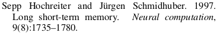

```python
Image(filename='images/bilstm.png')
```

> BiLSTMs are the core of modern Encoder-Decoder architectures. BiLSTMs get as input the sequence forward and backwards, which can result in faster learning.

### GCN

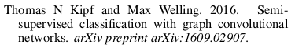

```python
Image(filename='images/gcn.png')
```

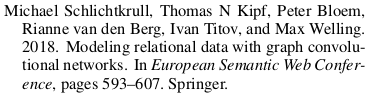

```python
Image(filename='images/gcn2.png')
```

> Both papers refer to GCN, the core part of the GraphIE-architecture.

### SeqIE

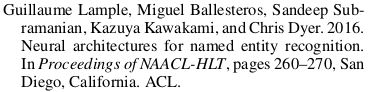

```python
Image(filename='images/seqie.png')
```

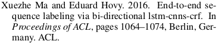

```python
Image(filename='images/seqie2.png')
```

> The architecture of SeqIE is the basis for the GraphIE-architecture and they already use conditional-random-fields (CRF), which was adapted by GraphIE.